# Using cta-seq to validate the Good-Turing estimator

# Introduction

In this script we will use the UMI-Tools corrected UMI counts of our cta-seq data to validate the Good-Turing estimator on scRNA-seq data.

We load the typical data from cta-seq run 1 and the data after amplification from cta-seq run 2 and construct a large tibble containing all data for analysis.

```r
umi_tools_cm <- readRDS('../data/umi_tools_corrected_deep_counts.RDS')

umi_tools_dgC <- umi_tools_cm %>% select(-gene) %>% as.matrix() %>% as('dgCMatrix')
rownames(umi_tools_dgC) <- umi_tools_cm$gene

my_cells <- as.character(str_glue('{read_csv("select_cells/barcodes.csv")$barcodes}-1'))

data_tbl <- tibble(data_folders = c('../cta_seq/outs/filtered_feature_bc_matrix/',
                                    '../cta_seq_run2/outs/filtered_feature_bc_matrix/'),
                   Dataset = c('typical', 'ultra-deep'),
                   cells = list(my_cells)) %>%
  mutate(raw_counts = map(data_folders, Read10X))

umi_tools_dgC_large <- matrix(0, ncol = 18, nrow = nrow(data_tbl$raw_counts[[1]])) %>% as('dgCMatrix')
rownames(umi_tools_dgC_large) <- rownames(data_tbl$raw_counts[[1]])
colnames(umi_tools_dgC_large) <- colnames(umi_tools_dgC)

for(i in rownames(umi_tools_dgC)){
  umi_tools_dgC_large[i,] <- umi_tools_dgC[i,]
}

data_tbl$raw_counts[[2]] <- umi_tools_dgC_large

write.csv2(umi_tools_dgC_large, file = '../data/cta-seq_ultra_deep.csv')
```

Next we calculate the relative expression for both the typical and the ultra-deep data-set. Using both the GT and ML estimator.

```r
data_tbl <- data_tbl %>%
  mutate(seurat_objects = map(raw_counts, CreateSeuratObject)) %>%
  mutate(seurat_objects = map(seurat_objects, partial(NormalizeData, normalization.method = 'RC', scale.factor = 1))) %>%
  mutate(seurat_objects = map(seurat_objects, partial(GTestimate, log1p.transform = F, size.factor = 1)))
```

# Summary

We can quickly summarize the data here:

```r
dir.create(str_glue('{folder}summary/'))
count_summary_tbl <- data_tbl %>%
  mutate(`#reads` = map2(raw_counts, cells, function(x, y) tibble(`#reads` = colSums(x)[y])),
         Feature_count = map2(raw_counts, cells, function(x, y) tibble(Feature_count = colSums(x != 0)[y])),
         missing_mass = map2(seurat_objects, cells, function(x, y) tibble(missing_mass = x$missing_mass[y]))) %>%
  select(Dataset, cells, `#reads`, Feature_count, missing_mass)

count_summary_tbl <- count_summary_tbl %>%
  unnest(c(cells, `#reads`, Feature_count, missing_mass))

#my_cell_ordering <- my_cells
my_cell_ordering <- count_summary_tbl %>% filter(Dataset == 'typical') %>% arrange(`#reads`) %>% pluck('cells')

count_summary_tbl <- count_summary_tbl %>%
  mutate(cells = factor(cells, levels = my_cell_ordering), Dataset = factor(Dataset, levels = c('ultra-deep', 'typical'))) %>%
  mutate(cell_barcodes = cells, cells = factor(as.numeric(cells), levels = 1:18))

count_summary_tbl %>% group_by(Dataset) %>% summarise(mean_umis = mean(`#reads`))
```

```
## # A tibble: 2 × 2
##   Dataset    mean_umis
##   <fct>          <dbl>
## 1 ultra-deep    44511
## 2 typical        6048.
```

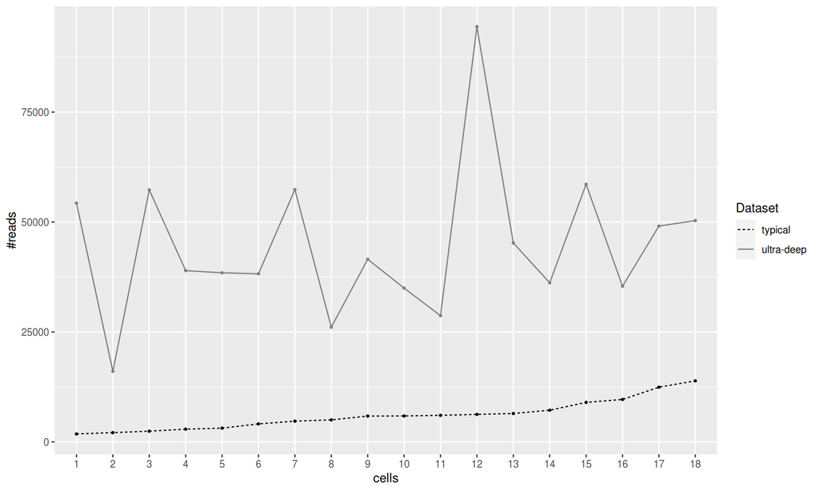

```r
count_plot <- ggplot(count_summary_tbl) +
  geom_line(aes(x = cells, y = `#reads`, linetype = Dataset, group = Dataset, col = Dataset)) +
  geom_point(aes(x = cells, y = `#reads`, col = Dataset), size = .7) +
  scale_linetype(breaks = c('typical', 'ultra-deep')) +
  scale_x_discrete(labels = 1:18) +
  scale_color_manual(values = c('gray50', 'black'), guide = 'none') +
  guides(linetype = guide_legend(override.aes = list(color = c('black', 'gray50'))))
ggsave(str_glue('{folder}summary/count_plot.pdf'), count_plot, width = 6.6, height = 4)
saveRDS(file = str_glue('{folder}summary/count_plot.Rds'), count_plot)
count_plot
```

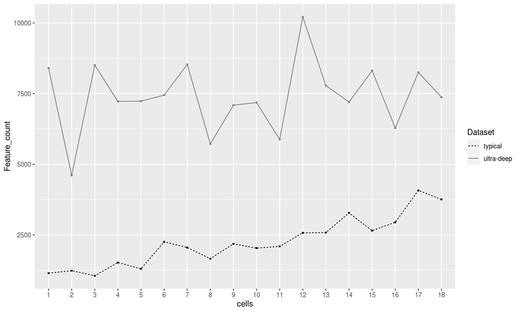

```r
feature_plot <- ggplot(count_summary_tbl) +
  geom_line(aes(x = cells, y = Feature_count, linetype = Dataset, group = Dataset, col = Dataset)) +
  geom_point(aes(x = cells, y = Feature_count, col = Dataset), size = .7) +
  scale_linetype(breaks = c('typical', 'ultra-deep')) +
  scale_x_discrete(labels = 1:18) +
  scale_color_manual(values = c('gray50', 'black'), guide = 'none') +
  guides(linetype = guide_legend(override.aes = list(color = c('black', 'gray50'))))
ggsave(str_glue('{folder}summary/feature_plot.pdf'), feature_plot, width = 6.6, height = 4)
saveRDS(file = str_glue('{folder}summary/feature_plot.Rds'), feature_plot)
feature_plot
```

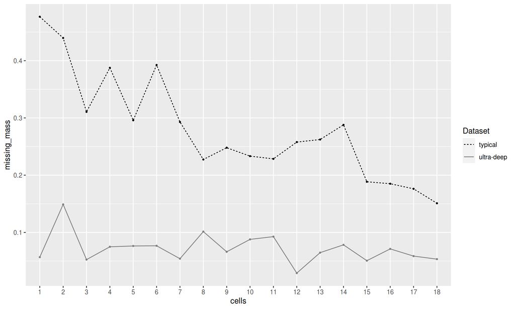

```r
mm_plot <- ggplot(count_summary_tbl) +
  geom_line(aes(x = cells, y = missing_mass, linetype = Dataset, group = Dataset, col = Dataset)) +
  geom_point(aes(x = cells, y = missing_mass, col = Dataset), size = .7) +
  scale_linetype(breaks = c('typical', 'ultra-deep')) +
  scale_x_discrete(labels = 1:18) +
  scale_color_manual(values = c('gray50', 'black'), guide = 'none') +
  guides(linetype = guide_legend(override.aes = list(color = c('black', 'gray50'))))
ggsave(str_glue('{folder}summary/mm_plot.pdf'), mm_plot, width = 6.6, height = 4)
saveRDS(file = str_glue('{folder}summary/mm_plot.Rds'), mm_plot)
mm_plot
```

# Raw reads

We can also look at the raw reads for our 18 cells, read_processing.sh has already counted these and saved them in ../data/deep_cbz_sorted.txt

```r
cb_counts_deep <- read_delim('../data/deep_cbz_sorted.txt',  delim = ' CB:Z:', col_names = c('raw_counts_deep', 'cell_barcodes'), col_types = 'nc')
cb_counts_deep <- cb_counts_deep %>%
  filter(cell_barcodes %in% my_cells)

cb_counts_deep
```

```
## # A tibble: 18 × 2
##    raw_counts_deep cell_barcodes
##              <dbl> <chr>
##  1        82551851 TCTCTGGGTGTGCTTA-1
##  2        31833676 AGTTCCCCAGGCCCTA-1
##  3        26677483 GAGTTACCAATAGGAT-1
##  4        25525932 GGCTTTCGTGTGTCGC-1
##  5        24793817 AATGACCGTGTGTGTT-1
##  6        22809673 TCATGTTTCCGCAACG-1
##  7        21888138 GGGAGATTCTTAAGGC-1
##  8        21547302 TATCGCCTCACATTGG-1
##  9        20009603 TAGACCAGTATTTCCT-1
## 10        19716241 CATTGCCCAGAGACTG-1
## 11        18198802 GAGAGGTAGACGGTTG-1
## 12        18017003 TGTTCTATCGGTAGAG-1
## 13        16350901 GGGTATTAGAGGTTTA-1
## 14        15908116 GTCTGTCTCGTAGGAG-1
## 15        15280035 TCTTGCGTCCTACGGG-1
## 16        12296440 ACGTCCTAGTGCCCGT-1
## 17         9159783 GAGAGGTAGGGAGGTG-1
## 18         5769077 GCTTGGGAGGGTAATT-1
```

```r
cb_counts_deep$raw_counts_deep %>% sum
```

```
## [1] 408333873
```

```r
cb_counts_normal <- read_delim('../data/normal_cbz_sorted.txt',  delim = ' CB:Z:', col_names = c('raw_count_normal', 'cell_barcodes'), col_types = 'nc')
cb_counts_normal <- cb_counts_normal %>%
  filter(cell_barcodes %in% my_cells)

cb_counts_normal
```

```
## # A tibble: 18 × 2
##    raw_count_normal cell_barcodes
##               <dbl> <chr>
##  1            37900 AGTTCCCCAGGCCCTA-1
##  2            35802 CATTGCCCAGAGACTG-1
##  3            26600 TATCGCCTCACATTGG-1
##  4            24277 GGCTTTCGTGTGTCGC-1
##  5            20912 GTCTGTCTCGTAGGAG-1
##  6            17361 TAGACCAGTATTTCCT-1
##  7            17059 GAGAGGTAGGGAGGTG-1
##  8            16334 GAGTTACCAATAGGAT-1
##  9            16126 TCTCTGGGTGTGCTTA-1
## 10            15796 GGGTATTAGAGGTTTA-1
## 11            14620 ACGTCCTAGTGCCCGT-1
## 12            12867 AATGACCGTGTGTGTT-1
## 13            12157 TGTTCTATCGGTAGAG-1
## 14             9207 TCTTGCGTCCTACGGG-1
## 15             8858 GGGAGATTCTTAAGGC-1
## 16             6873 TCATGTTTCCGCAACG-1
## 17             6599 GCTTGGGAGGGTAATT-1
## 18             6017 GAGAGGTAGACGGTTG-1
```

```r
cb_counts_normal$raw_count_normal %>% sum
```

```
## [1] 305365
```

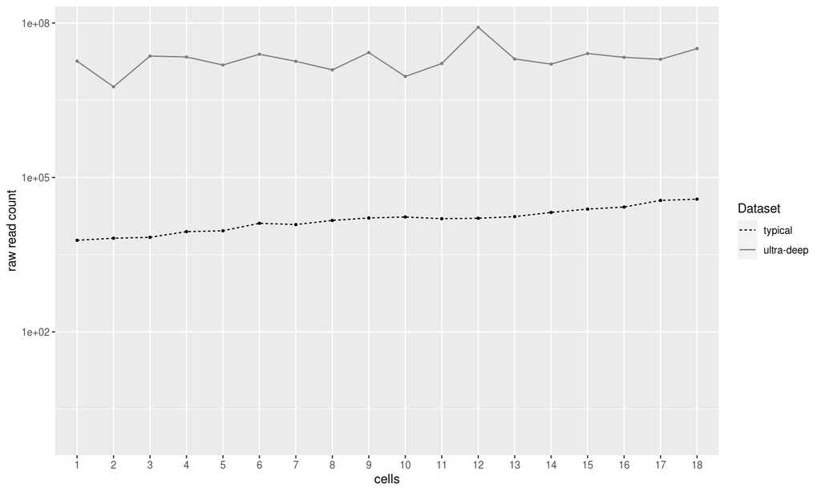

```r
read_summary_tbl <- count_summary_tbl %>%
  select(cells, cell_barcodes, `#reads`, Dataset) %>%
  pivot_wider(names_from = Dataset, values_from = `#reads`) %>%
  left_join(cb_counts_deep) %>%
  left_join(cb_counts_normal)

read_summary_tbl <- read_summary_tbl %>%
  pivot_longer(c(raw_counts_deep, raw_count_normal), names_to = 'Dataset', values_to = 'raw read count') %>%
  mutate(Dataset = fct_recode(Dataset,  `ultra-deep` = 'raw_counts_deep', typical = 'raw_count_normal')) %>%
  mutate(Dataset = fct_relevel(Dataset, c('ultra-deep', 'typical')))

read_summary_plot <- ggplot(read_summary_tbl) +
  geom_line(aes(x = cells, y = `raw read count`, linetype = Dataset, group = Dataset, col = Dataset)) +
  geom_point(aes(x = cells, y = `raw read count`, col = Dataset), size = .7) +
  scale_linetype(breaks = c('typical', 'ultra-deep')) +
  scale_y_continuous(limits = c(1, 85000000), trans = 'log10') +
  scale_color_manual(values = c('gray50', 'black'), guide = 'none') +
  guides(linetype = guide_legend(override.aes = list(color = c('black', 'gray50'))))

ggsave(str_glue('{folder}summary/read_summary_plot.pdf'), read_summary_plot, width = 6.6, height = 4)
saveRDS(file = str_glue('{folder}summary/read_summary_plot.Rds'), read_summary_plot)
read_summary_plot
```

# Relative gene expression estimation error

Next we will take a look at the errors made during relative expression estimation for both the GT and ML estimators:

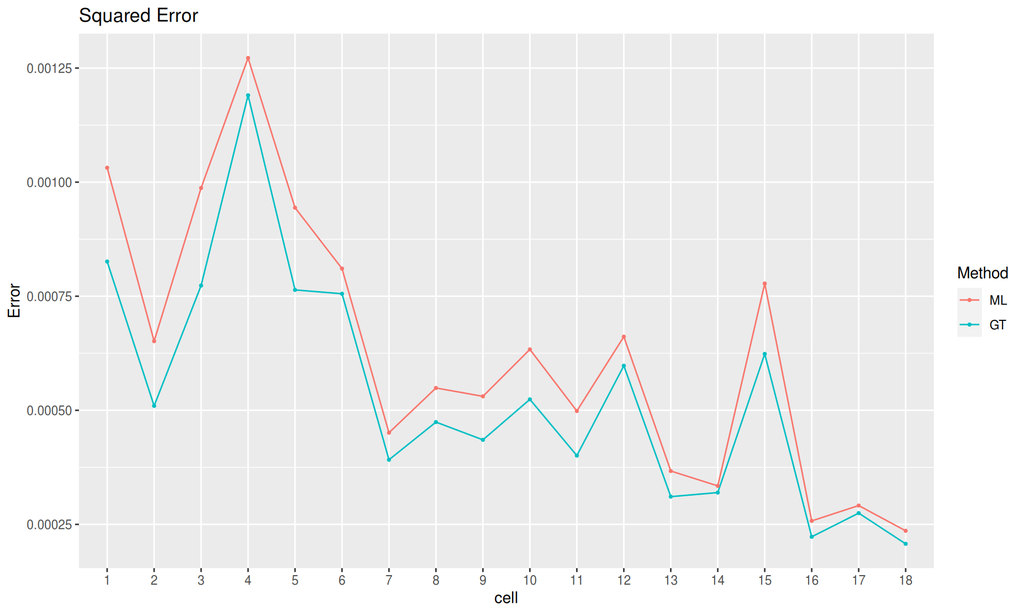

```r
dir.create(str_glue('{folder}re_estimation/'))

estimation_error_tbl <- bind_rows(map(my_cells, partial(calc_errors,
                                             typical_seurat = data_tbl$seurat_objects[[1]],
                                             deep_seurat = data_tbl$seurat_objects[[2]],
                                             metric = 'absolute'))) %>%
  rbind(bind_rows(map(my_cells, partial(calc_errors,
                                        typical_seurat = data_tbl$seurat_objects[[1]],
                                        deep_seurat = data_tbl$seurat_objects[[2]],
                                        metric = 'squared'))))

estimation_error_tbl <- estimation_error_tbl %>%
  mutate(cell = factor(cell, levels = my_cell_ordering))  %>%
  pivot_longer(!c(metric, cell), names_to = 'Method', values_to = 'Error') %>%
  mutate(Method = factor(Method, levels = c('ML', 'GT'))) %>%
  mutate(cell_barcodes = str_remove(cell, '-1'), cell = factor(as.numeric(cell), levels = 1:18))

squared_plot <- ggplot(estimation_error_tbl %>% filter(metric == 'squared')) +
  geom_line(aes(x = cell, y = Error, col = Method, group = Method)) +
  geom_point(aes(x = cell, y = Error, col = Method), size = .7) +
  ggtitle('Squared Error')

ggsave(str_glue('{folder}re_estimation/squared_plot.pdf'), squared_plot, width = 6.6, height = 4)
saveRDS(file = str_glue('{folder}re_estimation/squared_plot.Rds'), squared_plot)
squared_plot
```

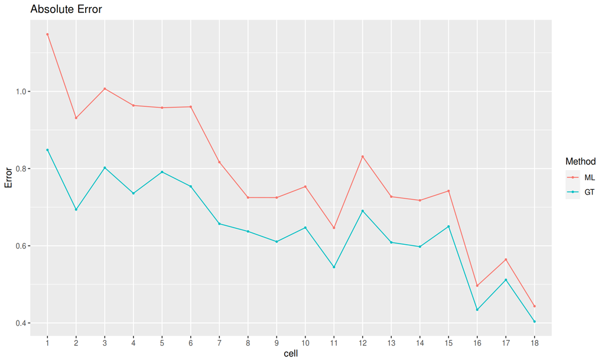

```r
absolute_plot <- ggplot(estimation_error_tbl %>% filter(metric == 'absolute')) +
  geom_line(aes(x = cell, y = Error, col = Method, group = Method)) +
  geom_point(aes(x = cell, y = Error, col = Method), size = .7) +
  ggtitle('Absolute Error')

ggsave(str_glue('{folder}re_estimation/absolute_plot.pdf'), absolute_plot, width = 6.6, height = 4)
saveRDS(file = str_glue('{folder}re_estimation/absolute_plot.Rds'), absolute_plot)
absolute_plot
```

```r
abs_improvement_tbl <- estimation_error_tbl %>%
  filter(metric == 'absolute') %>%
  pivot_wider(names_from = Method, values_from = Error) %>%
  mutate(Improvement = (ML-GT)/ML*100)
abs_improvement_tbl
```

```
## # A tibble: 18 × 6
##    metric   cell  cell_barcodes       ML    GT Improvement
##    <chr>    <fct> <chr>            <dbl> <dbl>       <dbl>
##  1 absolute 8     ACGTCCTAGTGCCCGT 0.725 0.637       12.1
##  2 absolute 15    GGCTTTCGTGTGTCGC 0.742 0.650       12.4
##  3 absolute 4     GGGAGATTCTTAAGGC 0.963 0.736       23.6
##  4 absolute 6     AATGACCGTGTGTGTT 0.960 0.754       21.5
##  5 absolute 17    CATTGCCCAGAGACTG 0.564 0.512        9.32
##  6 absolute 14    GTCTGTCTCGTAGGAG 0.718 0.598       16.7
##  7 absolute 10    GAGAGGTAGGGAGGTG 0.753 0.647       14.1
##  8 absolute 2     GCTTGGGAGGGTAATT 0.931 0.694       25.5
##  9 absolute 3     TCATGTTTCCGCAACG 1.01  0.802       20.3
## 10 absolute 1     GAGAGGTAGACGGTTG 1.15  0.848       26.1
## 11 absolute 13    TAGACCAGTATTTCCT 0.727 0.609       16.3
## 12 absolute 5     TCTTGCGTCCTACGGG 0.958 0.791       17.4
## 13 absolute 11    GGGTATTAGAGGTTTA 0.646 0.545       15.7
## 14 absolute 16    TATCGCCTCACATTGG 0.497 0.434       12.5
## 15 absolute 7     TGTTCTATCGGTAGAG 0.817 0.657       19.6
## 16 absolute 18    AGTTCCCCAGGCCCTA 0.443 0.404        8.94
## 17 absolute 9     GAGTTACCAATAGGAT 0.725 0.611       15.7
## 18 absolute 12    TCTCTGGGTGTGCTTA 0.831 0.690       16.9
```

```r
abs_improvement_tbl %>% summarise(`Average Improvement` = mean(Improvement))
```

```
## # A tibble: 1 × 1
##   `Average Improvement`
##                   <dbl>
## 1                  16.9
```

```r
cell_sizes <- read_summary_tbl %>%
  filter(Dataset == 'typical') %>%
  select(cell_barcodes, `raw read count`) %>%
  mutate(cell_barcodes = str_remove(cell_barcodes, pattern = '-1'))
```

we can also visualize for which genes we make the highest errors:

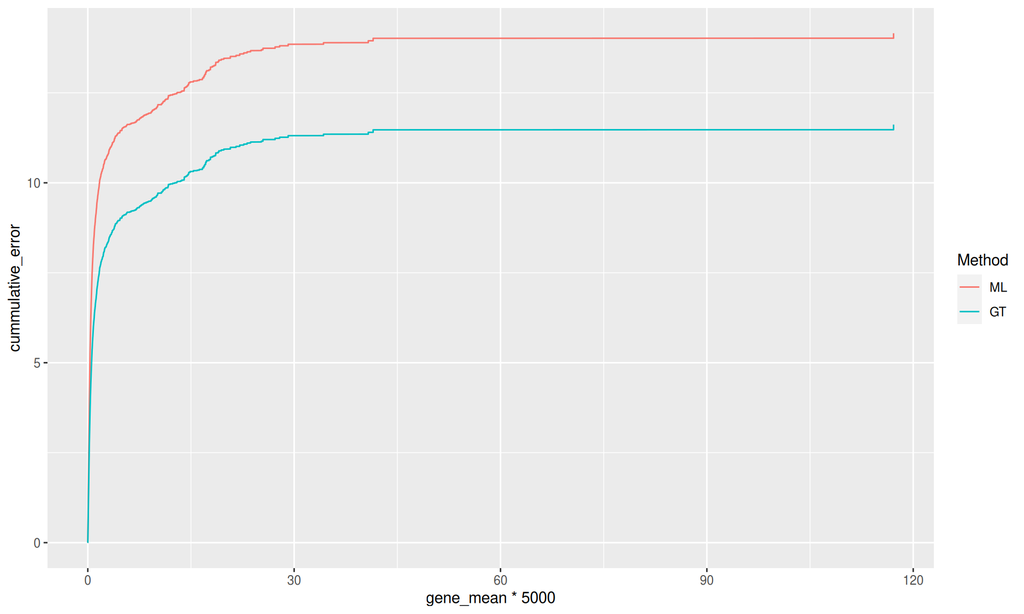

```r
ML_data <- GetAssayData(data_tbl$seurat_objects[[1]], assay = 'RNA', slot = 'data')[,my_cells]
ML_means <- rowMeans(ML_data)

GT_data <- GetAssayData(data_tbl$seurat_objects[[1]], assay = 'GTestimate', slot = 'data')[,my_cells]
GT_means <- rowMeans(GT_data)

deep_data <- GetAssayData(data_tbl$seurat_objects[[2]], assay = 'RNA', slot = 'data')[,my_cells]
deep_means <- rowMeans(deep_data)

deep_raw_means <- rowMeans(GetAssayData(data_tbl$seurat_objects[[2]], assay = 'RNA', slot = 'counts')[,my_cells])
ML_raw_means <- rowMeans(GetAssayData(data_tbl$seurat_objects[[1]], assay = 'RNA', slot = 'counts')[,my_cells])

something_expressed <- (ML_means + GT_means + deep_means) != 0

ML_data <- ML_data[something_expressed,]
GT_data <- GT_data[something_expressed,]
deep_data <- deep_data[something_expressed,]

ML_means <- data.frame(gene_mean = ML_means[something_expressed]) %>%
  rownames_to_column(var = 'gene') %>%
  as_tibble
GT_means <-  data.frame(gene_mean = GT_means[something_expressed]) %>%
  as.data.frame %>%
  rownames_to_column(var = 'gene') %>%
  as_tibble
deep_means <-  data.frame(gene_mean = deep_means[something_expressed]) %>%
  as.data.frame %>%
  rownames_to_column(var = 'gene') %>%
  as_tibble

deep_raw_means <-  data.frame(gene_mean = deep_raw_means[something_expressed]) %>%
  as.data.frame %>%
  rownames_to_column(var = 'gene') %>%
  as_tibble

ML_raw_means <-  data.frame(gene_mean = ML_raw_means[something_expressed]) %>%
  as.data.frame %>%
  rownames_to_column(var = 'gene') %>%
  as_tibble

individual_error_tbl_ML <- (abs(ML_data - deep_data)) %>%
  as.data.frame %>%
  rownames_to_column(var = 'gene') %>%
  as_tibble %>%
  pivot_longer(cols = !gene, values_to = 'Error', names_to = 'Cell') %>%
  left_join(deep_means) %>%
  arrange(gene_mean) %>%
  mutate(cummulative_error = cumsum(Error)) %>%
  mutate(Method = 'ML', expr_rank = row_number())

individual_error_tbl_GT <- (abs(GT_data - deep_data)) %>%
  as.data.frame %>%
  rownames_to_column(var = 'gene') %>%
  as_tibble %>%
  pivot_longer(cols = !gene, values_to = 'Error', names_to = 'Cell') %>%
  left_join(deep_means) %>%
  arrange(gene_mean) %>%
  mutate(cummulative_error = cumsum(Error)) %>%
  mutate(Method = 'GT', expr_rank = row_number())

individual_error_tbl <- rbind(individual_error_tbl_ML, individual_error_tbl_GT) %>%
  mutate(Method = factor(Method, levels = c('ML', 'GT')))

cummulative_expr_error <- ggplot(individual_error_tbl) + geom_line(aes(x=gene_mean*5000 , y= cummulative_error, col = Method))
ggsave(str_glue('{folder}re_estimation/cummulative_expr_error.pdf'), cummulative_expr_error, width = 6.6, height = 4)
saveRDS(file = str_glue('{folder}re_estimation/cummulative_expr_error.Rds'), cummulative_expr_error)
cummulative_expr_error
```

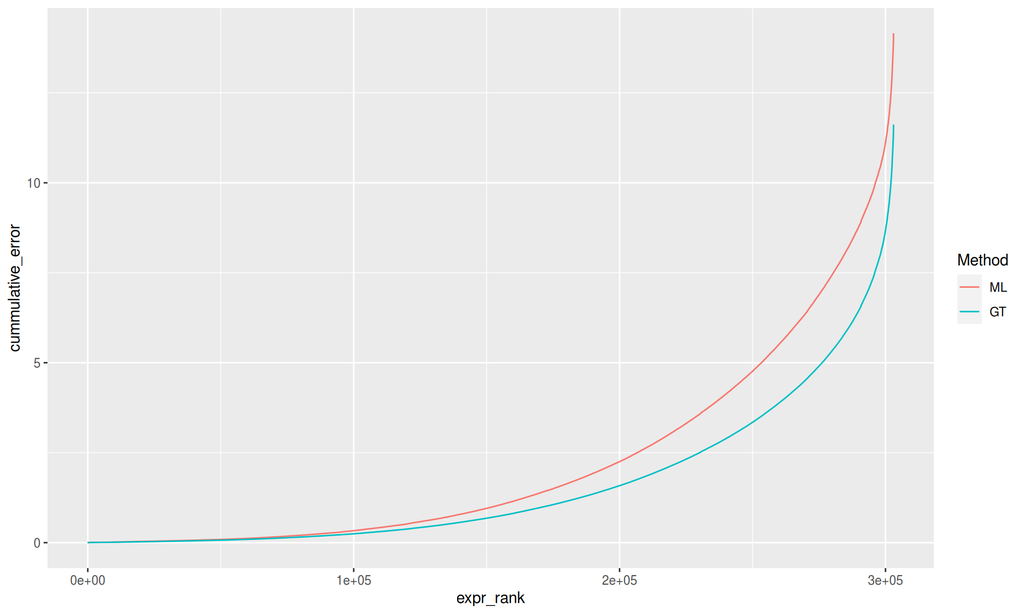

```r
cummulative_expr_error_ranked <- ggplot(individual_error_tbl) + geom_line(aes(x=expr_rank , y= cummulative_error, col = Method))
ggsave(str_glue('{folder}re_estimation/cummulative_expr_error_ranked.pdf'), cummulative_expr_error_ranked, width = 6.6, height = 4)
saveRDS(file = str_glue('{folder}re_estimation/cummulative_expr_error_ranked.Rds'), cummulative_expr_error_ranked)
cummulative_expr_error_ranked
```

# Pairwise Distance

Next we want to estimate the relative distances between cells and compare these distances to the ground-truth distances. This is usually done in PCA space after some additional pre-processing.

In order to keep these transformations consistent we will calculate them once for the full typical data-set and then apply the same transformations to the ultra-deep data-set.

```r
normal_data <- Read10X('../cta_seq/outs/filtered_feature_bc_matrix/') %>%
  CreateSeuratObject(min.cells = 100, min.features = 0) %>%
  AddMetaData(col.name = 'percent.mt', metadata = PercentageFeatureSet(., pattern = "^MT-")) %>%
  subset(subset = nFeature_RNA > 1000 & nFeature_RNA < 5000 & percent.mt < 8) %>%
  NormalizeData %>%
  FindVariableFeatures %>%
  ScaleData %>%
  RunPCA()
```

OK, now we ll apply the transformations:

```r
data_tbl_pca <- data_tbl %>%
  mutate(seurat_objects = map(raw_counts, function(x) CreateSeuratObject(x[rownames(normal_data), my_cells]))) %>%
  merge(tibble(Method = c('GT', 'ML'))) %>%
  as_tibble() %>%
  mutate(Method = factor(Method, levels = c('ML', 'GT')))

data_tbl_pca$seurat_objects[[1]] <- GTestimate(data_tbl_pca$seurat_objects[[1]], log1p.transform = T)
data_tbl_pca$seurat_objects[[2]] <- GTestimate(data_tbl_pca$seurat_objects[[2]], log1p.transform = T)
data_tbl_pca$seurat_objects[[3]] <- NormalizeData(data_tbl_pca$seurat_objects[[3]])
data_tbl_pca$seurat_objects[[4]] <- NormalizeData(data_tbl_pca$seurat_objects[[4]])

var_feats <- VariableFeatures(normal_data)

VariableFeatures(data_tbl_pca$seurat_objects[[1]]) <- var_feats
VariableFeatures(data_tbl_pca$seurat_objects[[2]]) <- var_feats
VariableFeatures(data_tbl_pca$seurat_objects[[3]]) <- var_feats
VariableFeatures(data_tbl_pca$seurat_objects[[4]]) <- var_feats

gene_means <- rowMeans(GetAssayData(normal_data, slot = 'data'))
gene_sds <- apply(GetAssayData(normal_data, slot = 'data'), 1, sd)

data_tbl_pca <- data_tbl_pca %>%
  mutate(seurat_objects = map(seurat_objects, function(x) manual_ScaleData(x, gene_means, gene_sds)))

data_tbl_pca <- data_tbl_pca %>%
  mutate(seurat_objects = map(seurat_objects, function(x) RunPCA(x, npcs = 5, verbose = F))) %>%
  mutate(seurat_objects = map(seurat_objects, function(x) project_pca(normal_data@reductions$pca, x)))

select_cell_tbl_pca <- data_tbl_pca %>%
  select(Dataset, Method, seurat_objects) %>%
  mutate(pca_embedding = map(seurat_objects, function(x) t(Embeddings(x, reduction = "pca")))) %>%
  select(!seurat_objects)

select_cell_tbl_pca <- as_tibble(merge(select_cell_tbl_pca, tibble(metric = c('euclidean', 'manhattan'))))

select_cell_tbl_pca <- select_cell_tbl_pca %>%
  mutate(dists = map2(pca_embedding, metric, function(x,y) as.data.frame(as.matrix(dist(t(x), method = y))))) %>%
  mutate(dists = map(dists, partial(rownames_to_column, var = 'Cell_A'))) %>%
  mutate(dists = map(dists, as_tibble)) %>%
  mutate(dists = map(dists, partial(pivot_longer, cols = !Cell_A, names_to = 'Cell_B', values_to = 'distance'))) %>%
  mutate(dists = map(dists, function(x) x %>% filter(Cell_A != Cell_B)))

select_cell_tbl_pca <- select_cell_tbl_pca %>%
mutate(dists = map(dists, function(x) x %>% mutate(Cell_A = fct_relevel(Cell_A, my_cells), Cell_B = fct_relevel(Cell_B, my_cells))))
```

We have calculated these transformations for the normal data-set and transferred them onto the ultra-deep and GT data-sets. Now we can calculate pairwise distances in PCA space and make the same plots.

First we can look at some heatmaps of thge distances, although they are hard to read:

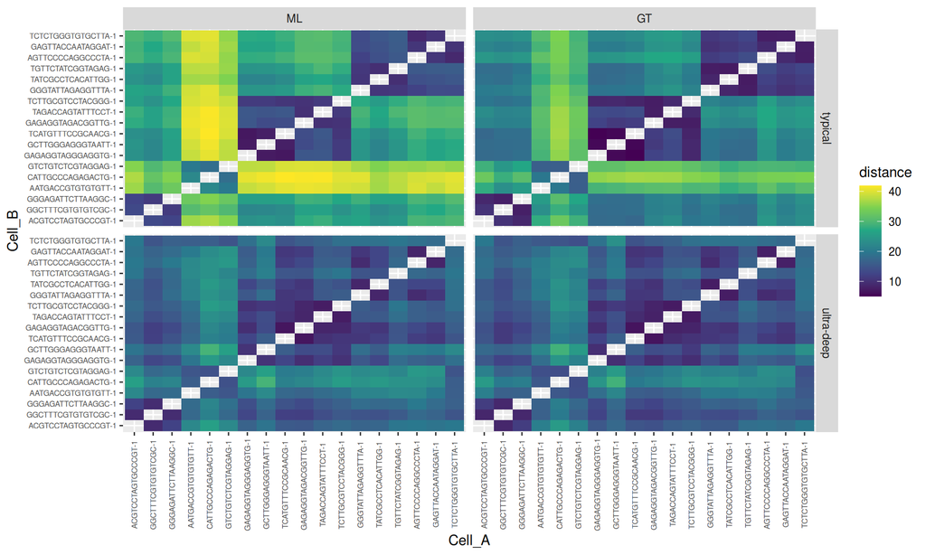

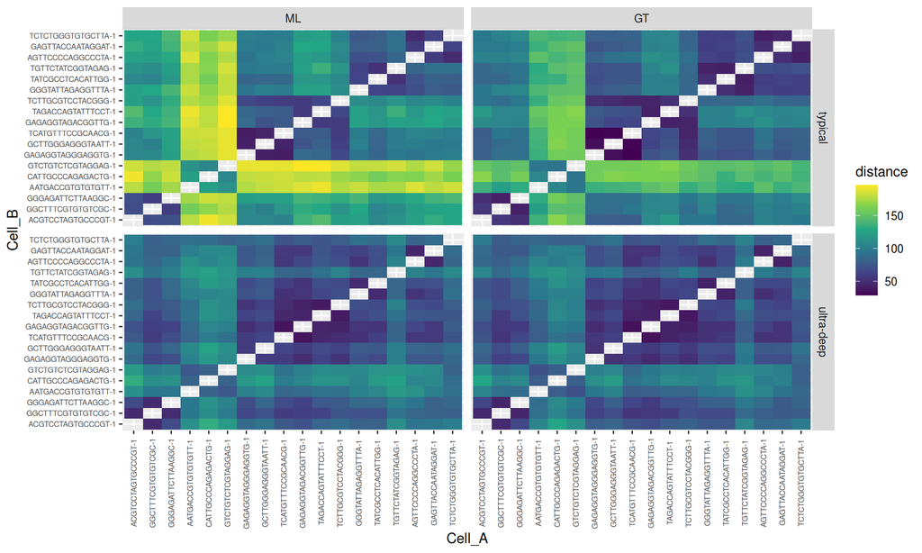

```r
dist_tbl_pca <- select_cell_tbl_pca %>%
  select(-pca_embedding) %>%
  unnest(dists)

dist_plots_pca <- dist_tbl_pca %>%
  group_by(metric) %>%
  summarise(heatmaps = list(ggplot(tibble(Cell_A, Cell_B, distance, Dataset, Method)) +
            geom_tile(aes(x = Cell_A, y = Cell_B, fill = distance)) +
            scale_fill_viridis_c() +
            theme(axis.text.x = element_text(angle = 90, vjust = 0.5, size = 6), axis.text.y = element_text(size = 6)) +
            facet_grid(vars(Dataset), vars(Method)))) %>%
  mutate(heatmap_files = pmap_chr(list(heatmaps, metric), function(x, y) save_plots(plot = x,
                                                                                             file_name = str_glue('combined_heatmap_{y}'),
                                                                                             folder_name = str_glue('{folder}cell_dists_pca/'),
                                                                                             width = 6.6,
                                                                                            height = 6.6)))
walk(dist_plots_pca$heatmaps, print)
```

Next a bit easier to read scatter plots:

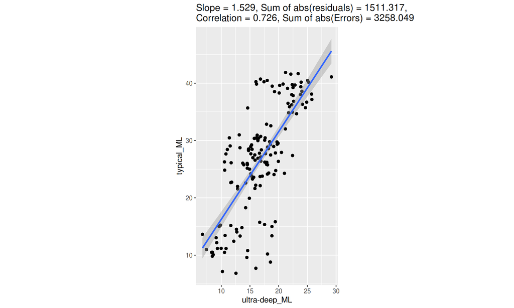

```r
dir_create(str_glue('{folder}scatter_plots'))
scatter_dist_tbl_pca <- dist_tbl_pca %>%
  filter(metric == 'euclidean') %>%
  mutate(Dataset_method = str_glue('{Dataset}_{Method}')) %>%
  select(-c(Dataset, Method)) %>%
  pivot_wider(names_from = Dataset_method, values_from = distance)

scatter_dist_tbl_pca_2 <- scatter_dist_tbl_pca %>%
  pivot_longer(cols = c(typical_ML, typical_GT), names_to = 'Method', values_to = 'distance_estimated') %>%
  rename(ground_truth_distance = `ultra-deep_ML`) %>%
  mutate(Method = str_replace(Method, 'typical_',''))

model_ML_pca <- lm(typical_ML ~ `ultra-deep_ML`, data = scatter_dist_tbl_pca)
scatter_ML_plot_pca <- ggplot(scatter_dist_tbl_pca) +
  geom_point(aes(x = `ultra-deep_ML` , y = typical_ML)) +
  geom_smooth(aes(x = `ultra-deep_ML`, y = typical_ML), method = 'lm') +
  ggtitle(str_glue('Slope = {model_ML_pca$coefficients[2] %>% round(digits = 3)}, Sum of abs(residuals) = {model_ML_pca$residuals %>% abs %>% sum %>% round(digits = 3)}, \n Correlation = {cor(scatter_dist_tbl_pca$typical_ML, scatter_dist_tbl_pca$`ultra-deep_ML`) %>% round(digits = 3)}, Sum of abs(Errors) = {sum(abs(scatter_dist_tbl_pca$typical_ML - scatter_dist_tbl_pca$`ultra-deep_ML`)) %>% round(digits = 3)}')) +
  coord_fixed()
scatter_ML_plot_pca
```

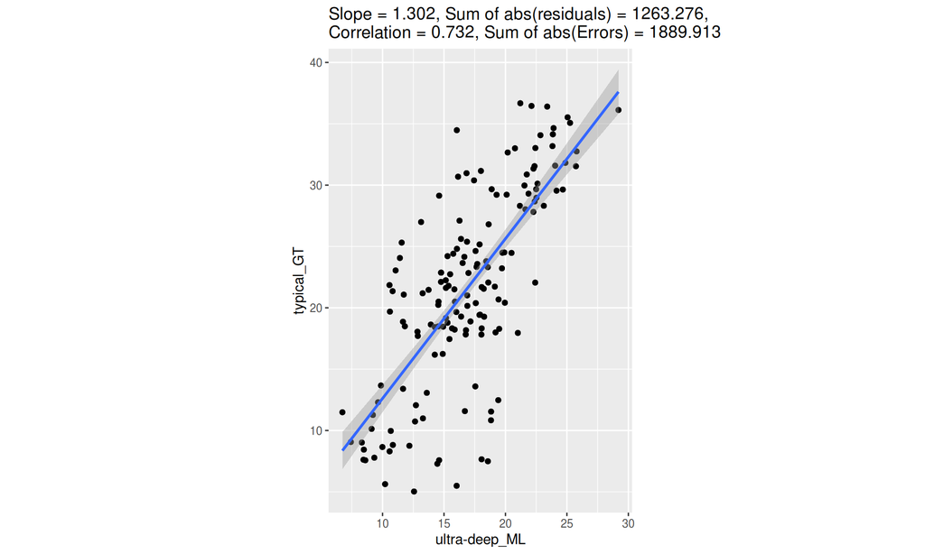

```r
ggsave(str_glue('{folder}scatter_plots/scatter_deep_ML_vs_typical_ML_pca.pdf'), scatter_ML_plot_pca, width = 6.6, height = 4)
saveRDS(file = str_glue('{folder}scatter_plots/scatter_deep_ML_vs_typical_ML_pca.Rds'), scatter_ML_plot_pca)

model_GT_pca <- lm(typical_GT ~ `ultra-deep_ML`, data = scatter_dist_tbl_pca)
scatter_GT_plot_pca <- ggplot(scatter_dist_tbl_pca) +
  geom_point(aes(x = `ultra-deep_ML` , y = typical_GT)) +
  geom_smooth(aes(x = `ultra-deep_ML`, y = typical_GT), method = 'lm') +
  ggtitle(str_glue('Slope = {model_GT_pca$coefficients[2] %>% round(digits = 3)}, Sum of abs(residuals) = {model_GT_pca$residuals %>% abs %>% sum %>% round(digits = 3)}, \n Correlation = {cor(scatter_dist_tbl_pca$typical_GT, scatter_dist_tbl_pca$`ultra-deep_ML`) %>% round(digits = 3)}, Sum of abs(Errors) = {sum(abs(scatter_dist_tbl_pca$typical_GT - scatter_dist_tbl_pca$`ultra-deep_ML`)) %>% round(digits = 3)}')) +
  coord_fixed()
scatter_GT_plot_pca
```

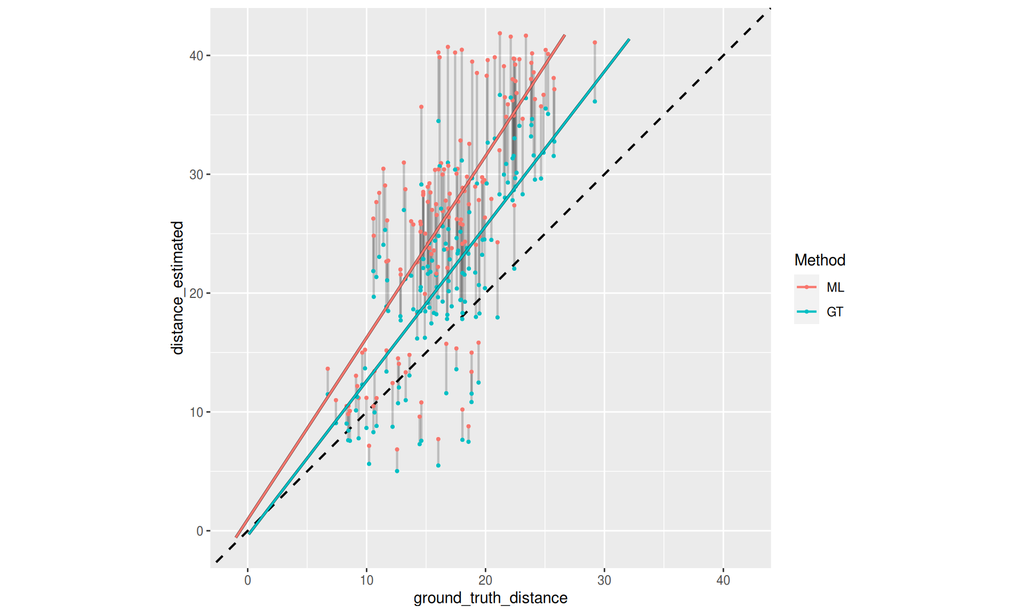

```r
ggsave(str_glue('{folder}scatter_plots/scatter_deep_ML_vs_typical_GT_pca.pdf'), scatter_GT_plot_pca, width = 6.6, height = 4)
saveRDS(file = str_glue('{folder}scatter_plots/scatter_deep_ML_vs_typical_GT_pca.Rds'), scatter_GT_plot_pca)

coord_limits_pca <- c(-1, max(c(scatter_dist_tbl_pca_2$ground_truth_distance, scatter_dist_tbl_pca_2$distance_estimated)))

model_ML_pca <- lm(typical_ML ~ `ultra-deep_ML`, data = scatter_dist_tbl_pca)
model_GT_pca <- lm(typical_GT ~ `ultra-deep_ML`, data = scatter_dist_tbl_pca)

scatter_plot_combined_pca <- ggplot(scatter_dist_tbl_pca_2 %>% mutate(Method = factor(Method, levels = c('ML','GT')))) +
  geom_abline(slope = 1, linetype = 2, linewidth = .75) +
  geom_line(aes(y = distance_estimated , x = ground_truth_distance, group = str_glue('{Cell_A}{Cell_B}')), alpha = 0.1, linewidth = .75) +
  geom_point(aes(y = distance_estimated , x = ground_truth_distance, col = Method), size = .7) +
  geom_smooth(aes(y = distance_estimated, x = ground_truth_distance, group = Method), col = 'black',method = 'lm', linewidth = .9, se = F, fullrange = T) +
  geom_smooth(aes(y = distance_estimated, x = ground_truth_distance, col = Method), method = 'lm', linewidth = .75, se = F, fullrange = T) +
  scale_x_continuous(limits = coord_limits_pca) +
  scale_y_continuous(limits = coord_limits_pca) +
  coord_fixed()
scatter_plot_combined_pca
```

```r
ggsave(str_glue('{folder}scatter_plots/scatter_combined_pca.pdf'), scatter_plot_combined_pca, width = 6.6, height = 4)
saveRDS(file = str_glue('{folder}scatter_plots/scatter_combined_pca.Rds'), scatter_plot_combined_pca)


ML_model_tbl <- tibble(Method = 'ML', Slope = model_ML_pca$coefficients[2] %>%
                         round(digits = 3),
                       `Sum of abs(residuals)` = model_ML_pca$residuals %>%
                         abs %>%
                         sum %>%
                         round(digits = 3),
                       Intercept = model_ML_pca$coefficients[1] %>%
                         round(digits = 3),
                       `Sum of abs(Errors)` = sum(abs(scatter_dist_tbl_pca$typical_ML - scatter_dist_tbl_pca$`ultra-deep_ML`)) %>%
                         round(digits = 3))

GT_model_tbl <- tibble(Method = 'GT', Slope = model_GT_pca$coefficients[2] %>%
                         round(digits = 3),
                       `Sum of abs(residuals)` = model_GT_pca$residuals %>%
                         abs %>%
                         sum %>%
                         round(digits = 3),
                       Intercept = model_GT_pca$coefficients[1] %>%
                         round(digits = 3),
                       `Sum of abs(Errors)` = sum(abs(scatter_dist_tbl_pca$typical_GT - scatter_dist_tbl_pca$deep_GT)) %>%
                         round(digits = 3))


model_tbl <- rbind(ML_model_tbl, GT_model_tbl)

write_lines(kable(model_tbl, format = 'latex'),file = str_glue('{folder}scatter_plots/pca_dists.tex'))
```